Sean Manaea had a rough beginning to the 2020 season, and there has been a lot of talk lately around his fastball velocity and how it seems to track closely with how well he pitches. A pitcher’s velocity is definitely important, but I don’t think the conversation on Manaea has hinged around the right thing. Instead of his fastball’s velocity, we should be talking more about his fastball’s movement.

If you want to follow along, all of the R code needed to collect, transform, analyze, and plot the data (and even build this post!) is in the [R Markdown file in the GitHub repository attached to this page](https://github.com/dlependorf/manaea_fb_movement/blob/master/README.Rmd).

## About Sean Manaea and his shoulder

Sean had shoulder surgery at the end of 2018, and at the time, [Jane Lee of MLB.com reported this](https://www.mlb.com/news/a-s-sean-manaea-has-shoulder-surgery-c295372404):

> Manaea, [A’s head trainer] Paparesta said, was dealing with chronic shoulder impingement for two years, worsening to the point where he couldn’t pitch without pain. The 26-year-old lefty was 12-9 with a 3.59 ERA in 27 starts this season, twirling a no-hitter against the Red Sox on April 21.

In theory, this means that Sean Manaea was healthy in 2016, and his shoulder started acting up in 2017 and 2018. If that’s true, we might be able to find this reflected in his how his fastball behaved across those years.

## Grabbing the data

To grab the pitch tracking data needed for this, I’m going to use Bill Petti’s fantastic baseballr R package, which comes with functions that grab raw pitch data from MLB via Baseball Savant. I’m also loading the [tidyverse](https://www.tidyverse.org/) suite of R packages. Note that as I write this, baseballr is not yet on the CRAN repository of R packages, so you’ll have to install it directly from its GitHub repo with `remotes::install_github("BillPetti/baseballr")`.

```r
library(tidyverse)
library(baseballr)
```

I’m going to loop over four and a half MLB seasons and use the baseballr::scrape_statcast_savant() function to grab the data I need.

```r
manaea_raw_data <- tribble(~start_date, ~end_date,
                           "2016-01-01", "2016-12-31",
                           "2017-01-01", "2017-12-31",
                           "2018-01-01", "2018-12-31",
                           "2019-01-01", "2019-12-31",
                           "2020-01-01", "2020-09-14") %>%
    # This mutate()/map2() call applies the scrape_statcast_savant() function to every start and end
    # date in the dataframe. The results for each row are put into a separate third column called
    # "data".
    mutate(data=map2(.x=start_date, .y=end_date,
                     ~scrape_statcast_savant(start_date=.x,
                                             end_date=.y,
                                             # This is Manaea's MLBAM player ID, which can be found
                                             # in the URL of any player's page on MLB.com.
                                             playerid=640455,
                                             player_type="pitcher"))) %>%
    # I don't actually need the dates any more, so the next two lines extract the Baseball Savant
    # data and bind them all together into one dataframe.
    pull(data) %>%
    bind_rows()
```

There’s a lot of data here, but I’m going to focus on pitch velocity, horizontal movement, and vertical movement, found in the **release_speed**, **pfx_x**, and **pfx_z** columns, respectively. I also saved the full manaea_raw_data dataset generated by the code block above [in the linked GitHub repository in CSV form here](https://github.com/dlependorf/manaea_fb_movement/blob/master/manaea_raw_data.csv), if you want to play with the data without pulling it all yourself.

## What did Sean look like before 2020?

A quick pitch movement explainer/refresher: fastballs come out of a pitcher’s hand with backspin. The more spin a pitcher is able to impart on a baseball, the more that ball will move during flight. These figures are relative to a spinless ball, meaning that a pitch with 10 inches of horizontal movement will move 10 inches leftward during flight relative to a spinless ball, from the perspective of the TV camera. When dealing with vertical movement, these figures don’t include the effect of gravity, so a pitch with 10 inches of vertical movement will “rise” 10 inches more than a spinless ball would. I use “rise” in quotes, because 10 inches of vertical upward movement isn’t enough to fully counteract how much a ball falls due to gravity, but it’s enough to make it fall less than it otherwise would.

So what has Manaea’s fastball looked like in the past?

```r
old_manaea_fb_only <- manaea_raw_data %>%
    # I'm extracting the season out of the game_date field, and I'm also converting the two
    # pfx_x/pfx_z movement fields from feet to inches.
    mutate(season=as.numeric(format(game_date, "%Y")),
           pfx_x=12*pfx_x,
           pfx_z=12*pfx_z) %>%
    filter(pitch_type=="FF",
           season < 2020)

old_manaea_fb_only %>%
    group_by(season) %>%
    summarize(fastballs=n(),
              release_speed=mean(release_speed),
              pfx_x=mean(pfx_x),
              pfx_z=mean(pfx_z),
              .groups="drop")
```

| season | fastballs | release_speed | pfx_x | pfx_z |
| --- | --- | --- | --- | --- |
| 2016 | 1268 | 92.89 | 17.27 | 12.55 |
| 2017 | 1556 | 91.69 | 14.09 | 10.57 |
| 2018 | 1313 | 90.44 | 14.32 | 9.92 |
| 2019 | 309 | 89.90 | 11.33 | 11.04 |

Sean was pitching through a shoulder impingement in 2017 and 2018 before having surgery after the 2018 season, and this absolutely lines up with how his fastball behaved: the pitch lost around a tick of velocity each year, and it also lost a few inches of movement in both directions while he was pitching through pain.

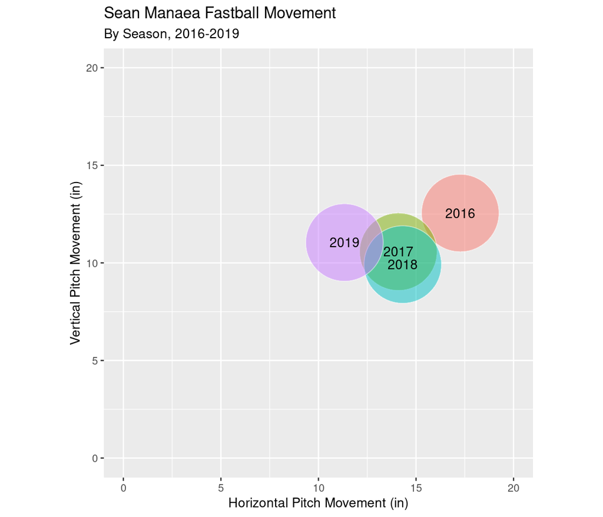

```r
old_manaea_fb_only_by_season <- old_manaea_fb_only %>%
    group_by(season) %>%
    summarize(release_speed=mean(release_speed),
              pfx_x=mean(pfx_x),
              pfx_z=mean(pfx_z),
              .groups="drop")

ggplot(old_manaea_fb_only_by_season) +
    geom_point(aes(x=pfx_x, y=pfx_z, fill=as.factor(season)),
               shape=21, alpha=0.5, size=30, color="transparent") +
    geom_text(aes(x=pfx_x, y=pfx_z, label=season)) +
    scale_x_continuous("Horizontal Pitch Movement (in)", limits=c(0, 20)) +
    scale_y_continuous("Vertical Pitch Movement (in)", limits=c(0, 20)) +
    coord_equal() +
    labs(title="Sean Manaea Fastball Movement",
         subtitle="By Season, 2016-2019") +
    theme(legend.position="none")
```

## Okay, so how about 2020?

```r
new_manaea_fb_only <- manaea_raw_data %>%
    mutate(season=as.numeric(format(game_date, "%Y")),
           pfx_x=12*pfx_x,
           pfx_z=12*pfx_z) %>%
    filter(pitch_type=="FF",
           season==2020)

new_manaea_fb_only_by_start <- new_manaea_fb_only %>%
    group_by(game_date) %>%
    summarize(fastballs=n(),
              release_speed=mean(release_speed),
              pfx_x=mean(pfx_x),
              pfx_z=mean(pfx_z),
              .groups="drop") %>%
    mutate(start_num=rank(game_date), .before="game_date")
```

| start_num | game_date | fastballs | release_speed | pfx_x | pfx_z |
| --- | --- | --- | --- | --- | --- |
| 1 | 2020-07-25 | 24 | 88.98 | 9.75 | 10.95 |
| 2 | 2020-07-31 | 49 | 90.02 | 10.78 | 11.49 |
| 3 | 2020-08-05 | 37 | 90.01 | 10.12 | 9.76 |
| 4 | 2020-08-10 | 35 | 90.93 | 10.11 | 11.83 |
| 5 | 2020-08-15 | 38 | 90.87 | 12.54 | 9.92 |
| 6 | 2020-08-20 | 37 | 89.04 | 13.85 | 8.85 |
| 7 | 2020-08-25 | 46 | 89.90 | 13.72 | 10.98 |
| 8 | 2020-09-05 | 37 | 92.12 | 13.72 | 10.25 |
| 9 | 2020-09-10 | 35 | 90.63 | 15.74 | 11.07 |

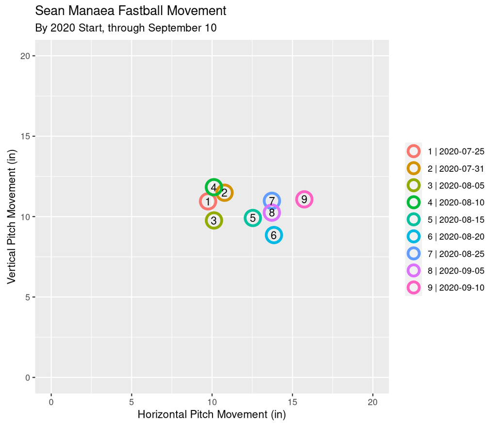

```r
ggplot(new_manaea_fb_only_by_start) +
    geom_point(aes(x=pfx_x, y=pfx_z, color=paste0(start_num, " | ", game_date)),
               shape=1, size=6, stroke=2) +
    geom_text(aes(x=pfx_x, y=pfx_z, label=start_num)) +
    scale_x_continuous("Horizontal Pitch Movement (in)", limits=c(0, 20)) +
    scale_y_continuous("Vertical Pitch Movement (in)", limits=c(0, 20)) +
    coord_equal() +
    guides(color=guide_legend(override.aes=list(size=4))) +
    labs(title="Sean Manaea Fastball Movement",
         subtitle="By 2020 Start, through September 10") +
    theme(legend.title=element_blank())
```

Sean has pretty drastically increased how much his fastball moves horizontally over the season, and I don’t think it’s a coincidence that this increase in movement has gone along with better pitching results. Adding horizontal movement results in increased “tail”, which is leftward movement from the perspective of the TV camera for a left-handed pitcher like Manaea.

With his latest start on September 10th, Manaea has been able to increase the amount of horizontal movement he’s getting on his fastball to the point where it’s legitimately close to where it was in 2016. Overlaying the two plots above makes this change more clear.

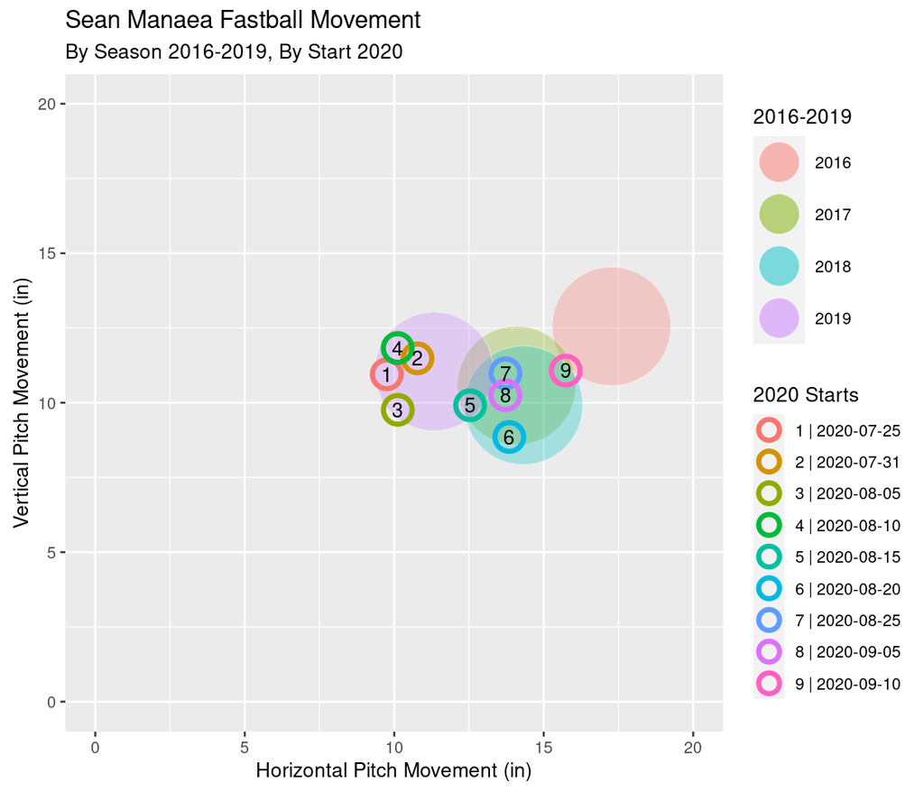

```r
ggplot() +
    geom_point(data=old_manaea_fb_only_by_season,
               aes(x=pfx_x, y=pfx_z, fill=as.factor(season)),
               shape=21, alpha=0.3, size=30, color="transparent") +
    geom_point(data=new_manaea_fb_only_by_start,
               aes(x=pfx_x, y=pfx_z, color=paste0(start_num, " | ", game_date)),
               shape=1, size=6, stroke=2) +
    geom_text(data=new_manaea_fb_only_by_start,
              aes(x=pfx_x, y=pfx_z, label=start_num)) +
    scale_x_continuous("Horizontal Pitch Movement (in)", limits=c(0, 20)) +
    scale_y_continuous("Vertical Pitch Movement (in)", limits=c(0, 20)) +
    coord_equal() +
    guides(color=guide_legend(override.aes=list(size=4)),
           fill=guide_legend(override.aes=list(size=10, alpha=0.5))) +
    labs(title="Sean Manaea Fastball Movement",
         subtitle="By Season 2016-2019, By Start 2020",
         color="2020 Starts",
         fill="2016-2019")
```

I don’t know how well Sean will pitch moving forward in 2020, but the movement on his fastball is absolutely something to keep a close eye on. This doesn’t mean that velocity isn’t important, but there are other ways to get outs than pure speed. Sean’s path forward from shoulder surgery may lie in spin and movement instead.